# Bayesian Inference for Multivariate Normal and Multiple Regression

AG Schissler

04/06/2020

## I. Start of class work

- Download today’s files (rmd, html, and any data)
- Run the `setup` chunk above and import ay data
- Please be prepared to try exercises in class.

There were lots of differing answers for the HW 8, problem 14.4 (especially parts h and i). Let’s discuss a solution to begin and agree on the answer.

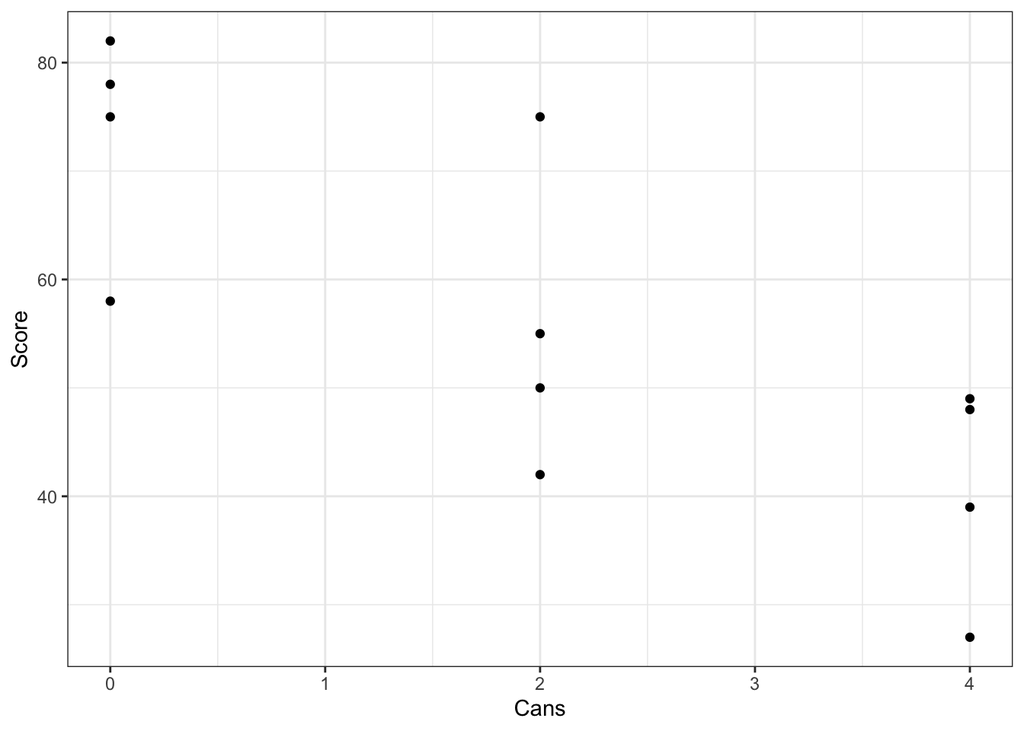

```r
dat144 <- data.frame( Cans = c(rep(0, 4), rep(2, 4), rep (4, 4)), Score = c(78, 82, 75, 58, 75, 42, 50, 55, 27, 48, 49, 39) )
## part A
ggplot2::qplot(x = Cans, y = Score, data = dat144)
```

```r
## part B
## Use built-in functions or code yourself
lm_fit <- lm(Score ~ Cans, data = dat144)
coef(lm_fit)
```

```
## (Intercept)        Cans
##      72.750      -8.125
```

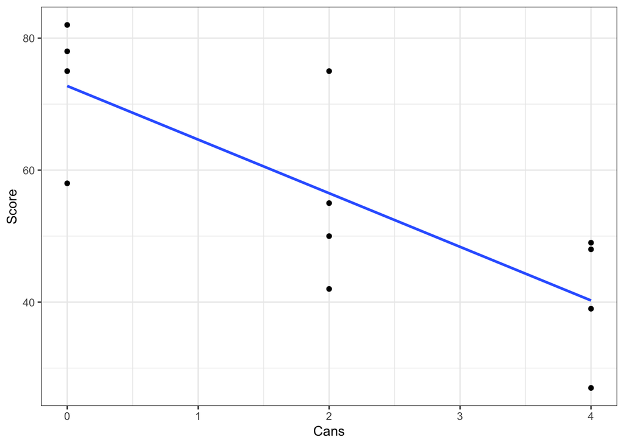

```r
## Part C
## or extract and use abline
## turning off frequentist error bars
ggplot2::qplot(x = Cans, y = Score, data = dat144) + ggplot2::geom_smooth(method = "lm", se = F)
```

```r
## Part D
sum(lm_fit$residuals^2)/ (nrow(dat144) - 2)
```

```
## [1] 124.65
```

```r
summary(lm_fit)$sigma^2
```

```
## [1] 124.65
```

```r
## Part E
sigma = 12
mb0 = 0
sb0 = 10
?bayes.lin.reg
bayes_fit <- bayes.lin.reg(y = dat144$Score, x = dat144$Cans, slope.prior = "normal",
                           intcpt.prior = "flat", mb0 = mb0, sb0 = sb0, sigma = sigma)
```

```
## Known standard deviation:  12
```

```
##             Posterior Mean Posterior Std. Deviation
##             -------------- ------------------------
## Intercept:  56.5           3.4641
## Slope:      -7.775         2.0751
```

```r
## why are the intercept estimators different?
## why are the slope estimators different?
bayes_fit$post.coef
```

```
## [1] 56.50000 -7.77512
```

```r
bayes_fit$post.coef.sd
```

```
## [1] 3.464102 2.075143
```

```r
summary(lm_fit)
```

```
##
## Call:
## lm(formula = Score ~ Cans, data = dat144)
##
## Residuals:
##     Min      1Q  Median      3Q     Max
## -14.750  -8.188   0.500   8.000  18.500
##
## Coefficients:
##             Estimate Std. Error t value Pr(>|t|)
## (Intercept)   72.750      5.096  14.276 5.62e-08 ***
## Cans          -8.125      1.974  -4.117  0.00209 **
## ---
## Signif. codes:  0 '***' 0.001 '**' 0.01 '*' 0.05 '.' 0.1 ' ' 1
##
## Residual standard error: 11.16 on 10 degrees of freedom
## Multiple R-squared:  0.6289, Adjusted R-squared:  0.5918
## F-statistic: 16.95 on 1 and 10 DF,  p-value: 0.002088
```

```r
## Part F
alpha = 0.05
c(bayes_fit$post.coef[2] - qnorm(1 - alpha / 2)* bayes_fit$post.coef.sd[2], bayes_fit$post.coef[2] + qnorm(1 - alpha / 2)* bayes_fit$post.coef.sd[2])
```

```
## [1] -11.842326  -3.707913
```

```r
## Part g
mu0 = 0
## lower.tail = FALSE since H0 is greater than or equal to 0.
pnorm(mu0, mean = bayes_fit$post.coef[2], sd = bayes_fit$post.coef.sd[2], lower.tail = FALSE)
```

```
## [1] 8.955714e-05
```

```r
## reject H0 in favor of H1
## part H
x13 = 3
bayes_fit <- bayes.lin.reg(y = dat144$Score, x = dat144$Cans, slope.prior = "normal",
                           intcpt.prior = "flat", mb0 = mb0, sb0 = sb0, sigma = sigma, pred.x = x13)
```

```
## Known standard deviation:  12
```

```
##             Posterior Mean Posterior Std. Deviation
##             -------------- ------------------------
## Intercept:  56.5           3.4641
## Slope:      -7.775         2.0751
```

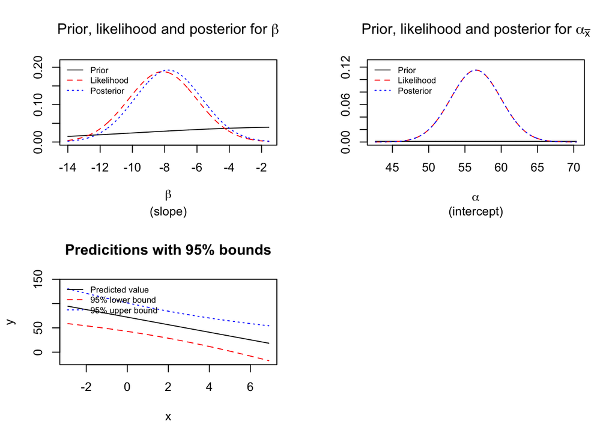

```
## x       Predicted y  SE
## ------  -----------  -----------
## 3         48.72        12.661
```

```r
## part I
alpha = 0.05
c(bayes_fit$pred.y - qnorm(1 - alpha / 2)* bayes_fit$pred.se, bayes_fit$pred.y + qnorm(1 - alpha / 2)* bayes_fit$pred.se)
```

```
## [1] 23.90937 73.54039
```

## Bayesian Inference for Multivariate Normal Mean (Ch. 18)

- This is necessary background information to understand Bayesian inference for the multiple linear regression model (more than 1 predictor).
- But that doesn’t do the multivariate normal (MVN) distribution justice!
- It is one of the most powerful modeling framework with applications arises naturally for many types of measurement and many statistical asymptotic results.
- Bolstad begins with a bivariate normal discussion (2D) and then generalizes to $p$-dimensional spaces (multivariate).
- The MVN is evaluated at $p$-dimensional point and assigns probability weight to points in the space.
- It is parametrized by a mean vector $\mu$ the and variance-covariance matrix $\Sigma$.

Let’s briefly discuss the following sections in turn.

### Section 18.1 Bivariate Normal Density

### Section 18.2 Multivariate Normal Distribution

### Section 18.3 Posterior of MVN Mean Vector with $\Sigma$ known

### Section 18.4 Credible region

### Section 18.5 Posterior of MVN Mean Vector with $\Sigma$ unknown

This section can be omitted but is recommended reading.

### Discuss HW 9 Ch. 14 C1-C3

Quick Discussion

## Bayesian Inference for Multiple Normal Linear Regression Model (Ch. 19)

Let’s begin this discussion by way of example then I briefly discuss the mathematics.

```r
example(bayes.lm)
```

```
##
## bys.lm> data(bears)
##
## bys.lm> bears = subset(bears, Obs.No==1)
##
## bys.lm> bears = bears[,-c(1,2,3,11,12)]
##
## bys.lm> bears = bears[ ,c(7, 1:6)]
##
## bys.lm> bears$Sex = bears$Sex - 1
##
## bys.lm> log.bears = data.frame(log.Weight = log(bears$Weight), bears[,2:7])
##
## bys.lm> b0 = rep(0, 7)
##
## bys.lm> V0 = diag(rep(1e6,7))
##
## bys.lm> fit = bayes.lm(log(Weight)~Sex+Head.L+Head.W+Neck.G+Length+Chest.G, data = bears,
## bys.lm+                prior = list(b0 = b0, V0 = V0))
```

```
##
## bys.lm> summary(fit)
##
## Call:
## bayes.lm(formula = log(Weight) ~ Sex + Head.L + Head.W + Neck.G +
##      Length + Chest.G, data = bears, prior = list(b0 = b0, V0 = V0))
##
## Residuals:
##      Min       1Q   Median       3Q      Max
## -0.62638 -0.08295  0.02390  0.09789  0.21932
##
## Coefficients:
##              Posterior Mean  Std. Error  t value
## (Intercept)  5.043e+00       2.192e-04   2.300e+04
## Sex          2.092e-02       1.140e-03   1.834e+01
## Head.L       1.407e-03       3.321e-04   4.237e+00
## Head.W       8.746e-03       3.521e-04   2.484e+01
## Neck.G       1.949e-02       9.273e-05   2.102e+02
## Length       2.472e-02       1.706e-05   1.449e+03
## Chest.G      3.424e-02       3.101e-05   1.104e+03
## ---
## Prior Coefficients:
## (Intercept)          Sex       Head.L       Head.W       Neck.G       Length
##           0            0            0            0            0            0
##     Chest.G
##           0
##
## Prior Covariance Matrix:
##              (Intercept)  Sex    Head.L  Head.W  Neck.G  Length  Chest.G
## (Intercept)  1e+06        0e+00  0e+00   0e+00   0e+00   0e+00   0e+00
## Sex          0e+00        1e+06  0e+00   0e+00   0e+00   0e+00   0e+00
## Head.L       0e+00        0e+00  1e+06   0e+00   0e+00   0e+00   0e+00
## Head.W       0e+00        0e+00  0e+00   1e+06   0e+00   0e+00   0e+00
## Neck.G       0e+00        0e+00  0e+00   0e+00   1e+06   0e+00   0e+00
## Length       0e+00        0e+00  0e+00   0e+00   0e+00   1e+06   0e+00
## Chest.G      0e+00        0e+00  0e+00   0e+00   0e+00   0e+00   1e+06
##
## bys.lm> print(fit)
##
## Call:
```

[output cut: 8 more lines]

```
##    0.034235
##
##
## bys.lm> ## Dobson (1990) Page 9: Plant Weight Data:
## bys.lm> ctl <- c(4.17,5.58,5.18,6.11,4.50,4.61,5.17,4.53,5.33,5.14)
##
## bys.lm> trt <- c(4.81,4.17,4.41,3.59,5.87,3.83,6.03,4.89,4.32,4.69)
##
## bys.lm> group <- gl(2, 10, 20, labels = c("Ctl","Trt"))
##
## bys.lm> weight <- c(ctl, trt)
##
## bys.lm> lm.D9 <- lm(weight ~ group)
##
## bys.lm> bayes.D9 <- bayes.lm(weight ~ group)
```

```
##
## bys.lm> summary(lm.D9)
##
## Call:
## lm(formula = weight ~ group)
##
## Residuals:
##     Min      1Q  Median      3Q     Max
## -1.0710 -0.4938  0.0685  0.2462  1.3690
##
## Coefficients:
##             Estimate Std. Error t value Pr(>|t|)
## (Intercept)   5.0320     0.2202  22.850 9.55e-15 ***
## groupTrt     -0.3710     0.3114  -1.191    0.249
## ---
## Signif. codes:  0 '***' 0.001 '**' 0.01 '*' 0.05 '.' 0.1 ' ' 1
##
## Residual standard error: 0.6964 on 18 degrees of freedom
## Multiple R-squared:  0.07308,    Adjusted R-squared:  0.02158
## F-statistic: 1.419 on 1 and 18 DF,  p-value: 0.249
##
##
## bys.lm> summary(bayes.D9)
##
## Call:
## bayes.lm(formula = weight ~ group)
##
## Residuals:
##     Min      1Q  Median      3Q     Max
## -1.0710 -0.4938  0.0685  0.2462  1.3690
##
## Coefficients:
##              Posterior Mean  Std. Error  t value
## (Intercept)    4.84650         0.02425   199.87284
## group         -0.37100         0.09699    -3.82507
## ---
##
## Note: No prior given (Using flat prior).
```

### Discuss HW 10 Ch. 15

Let me give some hints to begin.

## Closing (5 min)

- What are some issues in HW that you could use guidance on?